# Who’s the Victim in a US-China Trade War?

## What does a trade war entail for these states?

Microeconomic theory can be of some help to us here in describing the fundamental mechanisms operating during a trade war. Domestic businesses are usually price-takers from a global market, which with China’s help has made many goods cheaper. As a result, more consumers have been able to buy cheaper goods. When a tariff is introduced, prices go up and quantity goes down, hurting the consumer by increasings costs and threfore reducing the number of people who may buy certian goods. Meanwhile, domestic suppliers can become more competitive, and can begin to reap the benefits of higher consumer costs. However, we lose some potential surplus in dead weight losses, which ends up hurting consumers, producers, and the government in the long run.

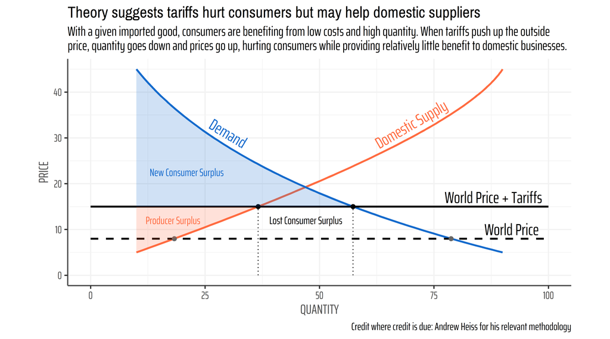

```r
# credit to Andrew Heiss for creating this package: https://github.com/andrewheiss/reconPlots
library(devtools)
library(reconPlots)

line1 <- data.frame(Hmisc::bezier(c(10, 80, 90), c(5, 30, 45)))
line2 <- data.frame(Hmisc::bezier(c(10, 30, 90), c(45, 20, 5)))
line3 <- data.frame(Hmisc::bezier(c(0, 100), c(8, 8)))
line4 <- data.frame(Hmisc::bezier(c(0, 100), c(15, 15)))

line_intersect <- as.data.frame(curve_intersect(line1, line2))
base_intersect1 <- as.data.frame(curve_intersect(line1, line3))
base_intersect2 <- as.data.frame(curve_intersect(line2, line3))
new_intersect1 <- as.data.frame(curve_intersect(line1, line4))
new_intersect2 <- as.data.frame(curve_intersect(line2, line4))

ggplot(mapping = aes(x = x, y = y)) +
  geom_path(data = line1, color = "#FF6B40", size = 1) +
  geom_path(data = line2, color = "#146ACC", size = 1) +
  geom_path(data = line3, color = "black", linetype = 'dashed', size = 1) +
  geom_path(data = line4, color = "black", size = 1) +
  geom_point(data = base_intersect1, size = 2, color = 'grey40') +
  geom_point(data = base_intersect2, size = 2, color = 'grey40') +
  geom_point(data = new_intersect1, size = 2, color = 'black') +
  geom_point(data = new_intersect2, size = 2, color = 'black') +
  geom_ribbon(data = subset(line2, line2$x <= 57.33401),
      aes(ymin = 15, ymax = y), fill = '#146ACC', alpha = .2) +
  geom_ribbon(data = subset(line1, line1$x <= 36.60526),
      aes(ymin = y, ymax = 15), fill = '#FF6B40', alpha = .2) +
  geom_segment(data = new_intersect1,
      aes(x = x, y = 0, xend = x, yend = y), lty = "dotted") +
  geom_segment(data = new_intersect2,
      aes(x = x, y = 0, xend = x, yend = y), lty = "dotted") +  coord_equal() +
  annotate("text", x = 88, y = 17, label = 'World Price + Tariffs', family = "Saira ExtraCondensed", size = 6, color = 'black') +
  annotate("text", x = 70, y = 33, angle = 30, label = 'Domestic Supply', family = "Saira ExtraCondensed", size = 6, color = '#FF6B40') +
  annotate("text", x = 30, y = 31, angle = -31, label = 'Demand', family = "Saira ExtraCondensed", size = 6, color = '#146ACC') +
  annotate("text", x = 47, y = 12, label = 'Lost Consumer Surplus', family = "Saira ExtraCondensed", color = 'black', size = 4) +
  annotate("text", x = 92, y = 10, label = 'World Price', family = "Saira ExtraCondensed", size = 6, color = 'black') +
  annotate("text", x = 21, y = 22.5, label = 'New Consumer Surplus', family = "Saira ExtraCondensed", color = '#146ACC', size = 4) +
  annotate("text", x = 18, y = 12, label = 'Producer Surplus', family = "Saira ExtraCondensed", color = '#FF6B40', size = 4) +
  labs(x = 'QUANTITY', y = 'PRICE',
       title = 'Theory suggests tariffs hurt consumers but may help domestic suppliers',
       subtitle = 'With a given imported good, consumers are benefiting from low costs and high quantity. When tariffs push up the outside \nprice, quantity goes down and prices go up, hurting consumers while providing relatively little benefit to domestic businesses.',
       caption = 'Credit where credit is due: Andrew Heiss for his relevant methodology')
```